# Predicting Spotify Hits

## Describing the Predictors

Some of the names of the predictors can be confusing and are not so much self-explanatory. Thus, we will be providing definition of all important parameters in this section. Further details can also be found in the Kaggle page.

- `artist_tier`: Classification of tier the artists belongs to depending on how popular the artist is, based on the number fo listeners, takes values from “S”, “A”, “B”, “C”, “F” as degree of popularity, and “U” for upcoming artists which are newer and the listener data is not acquired.
- `pop`: Classification of the performance of songs, takes values from “hit”, “regular”, and “flop”
- `year`: The released year of the song (2000 to 2023)
- `danceability`: Track suitability for dancing (0.0 to 1.0)
- `energy`: Measure of intensity and activity (0.0 to 1.0)
- `key`: The key track is in (-1 to -11)
- `loudness`: Loudness in decibels range (-60 to 0 dB)
- `mode`: Modality of track (Major’1’/Minor’0’)
- `speechiness`: Presence of spoken words in a track
- `acousticness`: Confidence measure from 0 to 1 to declare if track is acoustic
- `instrumentalness`: Whether track contains vocals (0.0 to 1.0)
- `liveness`: Presence of audience in recording (0.0 to 1.0)
- `valence`: Musical positiveness (0.0 to 1.0)
- `tempo`: Tempo of tracks in beats per minute (BPM)
- `duration_ms`: Duration of track in milliseconds
- `time_signature`: Estimated time signature (3 to 7)

## Visual EDA

To get a better idea of our variables and the interaction and correlation between them, we create several graphs to visualize the properties and relations among our data set.

### Pop Distribution

First, lets take a look at the distribution of the three classes to ensure that they are well balanced. Since we defined the proportions of different classifications, the distribution should be exactly the 0.5/30.93/68.57 split. The graph should match the graph in the previous section.

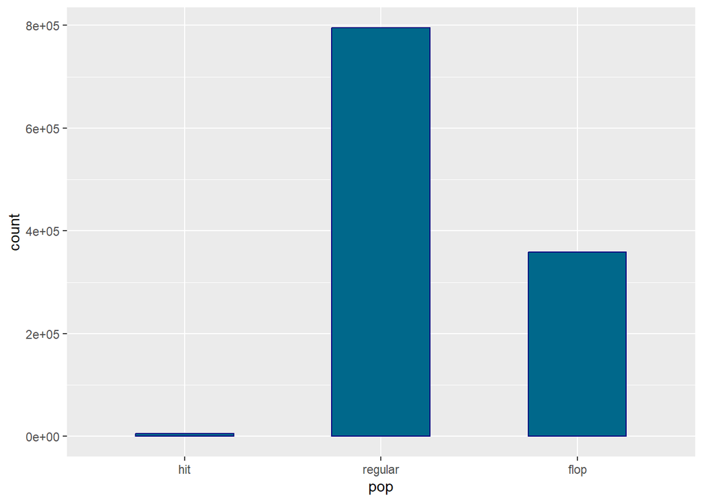

```r
#create bar pot of pop
song_data %>% ggplot(aes(x = pop)) + geom_bar(width =0.5, fill = "deepskyblue4", color = "navy")
```

As shown in graph, the distribution did follow our definition, with only 0.5% of the tracks being hits, and around 31% of the worst performed songs being flops.

### Variable Correlation Plot

Now we take a look at the correlation of the numeric variables and try to explain the phenomenon we observe.

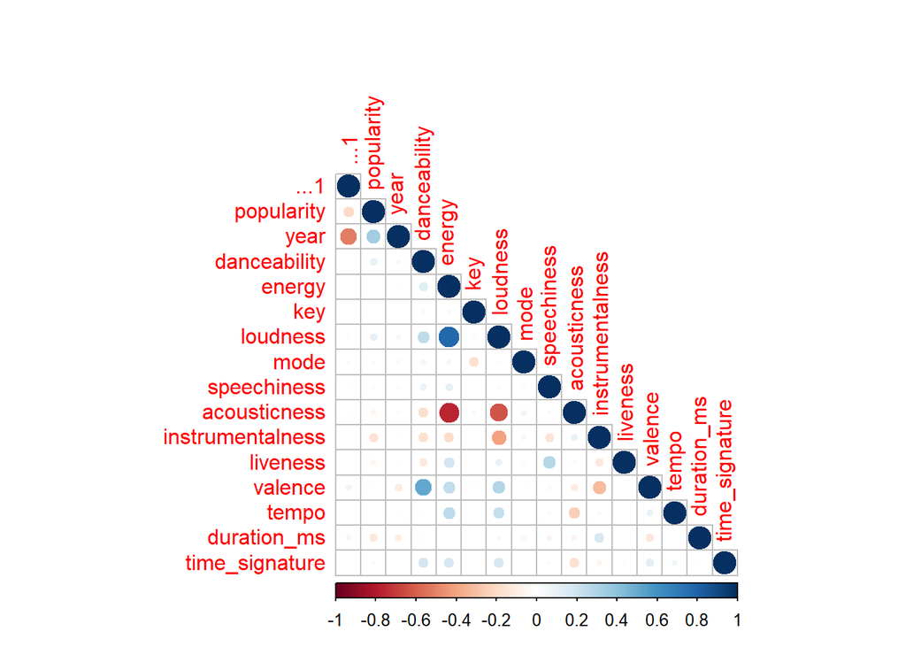

```r
#take only the numeric columns from song_data
song_data_numeric = song_data %>%
  select_if(is.numeric) %>%
  select(-popularity_quantile, -oldest_song)

#compute the correlation matrix
correlation_matrix = cor(song_data_numeric)

#plot lower triangle correlation matrix
corrplot(correlation_matrix, type = "lower")
```

Surprisingly, not many predictors are strongly correlated to each other. What’s worth noting is that, `acousticness` has a relatively strong negative correlation with `energy` and `loudness`. This makes sense because if a song is “acoustic”, the song is usually more on the quiet side to be enjoyed in a relaxed setting, which is the exact opposite of songs that are louder or has more energy as one would expect to hear at a party. For the same reason, `instrumentalness` is negatively correlated to `loudness` as well. Also, `energy` and `loudness` are strongly and positively correlated to each other, this is also imaginable as these are both qualities of songs that tend to be played in a party setting or a high energy occasion. Lastly, `dancability` and `valence` are positively correlated, the best explanation might be that a song having a higher valence value is “happier”, which makes people want to dance to it, resulting in a higher `dancability` as well.

### Artist Tier

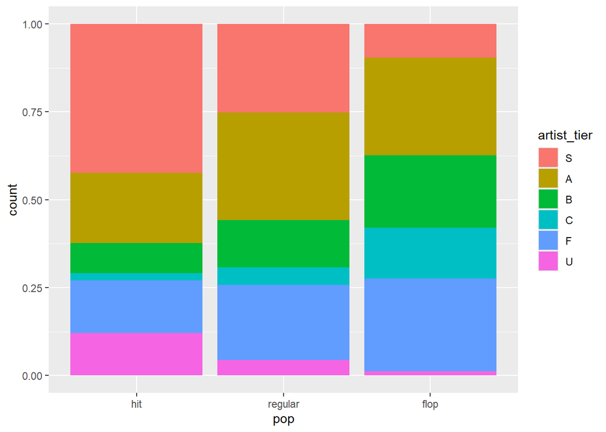

```r
#create a percentage stacked bar plot
song_data %>%
  ggplot(aes(fill = artist_tier, x = pop)) + geom_bar(position = "fill")
```

The data presented shows the distribution of `artist_tier` in the three category of popularity. As expected, the largest portion of hits are made by `S` tier artists, which makes perfect sense since if an artist is already very famous, then their new songs are very likely to be new hits. Also, note that there are more portion of `F` tier artists making hit than `C` tier artists making hits, this might be because F tier just has a larger size and also the existence of “one hit wonders”.

### Log Instrumentalness

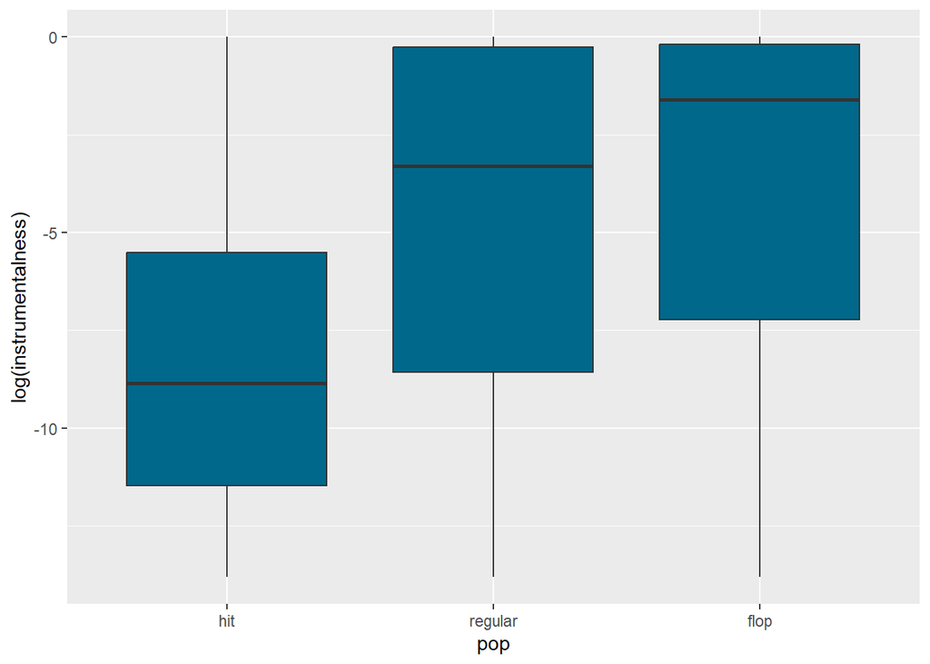

```r
#create box plot of energy and pop
song_data %>%
  ggplot(aes(x = pop, y = log(instrumentalness))) +
  geom_boxplot(fill = "deepskyblue4") +
  labs(x = "pop")
```

Realize that the distribution of log(instrumentalness) is significantly lower for hits than the other two categories. This indicates that if a song has a lower instrumentalness, they have a larger chance of becoming a hit.

### Danceability

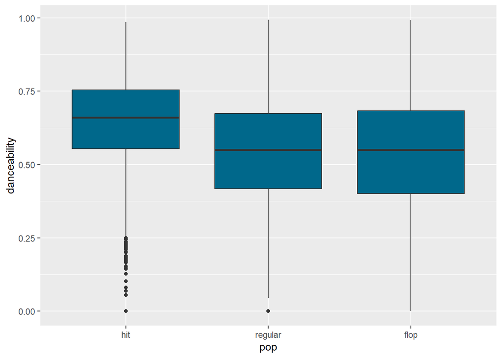

```r
#create box plot of danceability and pop
song_data %>%
  ggplot(aes(x = pop, y = danceability)) +
  geom_boxplot(fill = "deepskyblue4") +
  labs(x = "pop")
```

From the graph, we can tell that hits tend to have more danceability than the other two categories in general. This makes sense since if a song is more danceable, it might be played in a lot more occasions, such as parties, performances, online contents, which increases the popularity of the songs.

### Acousticness

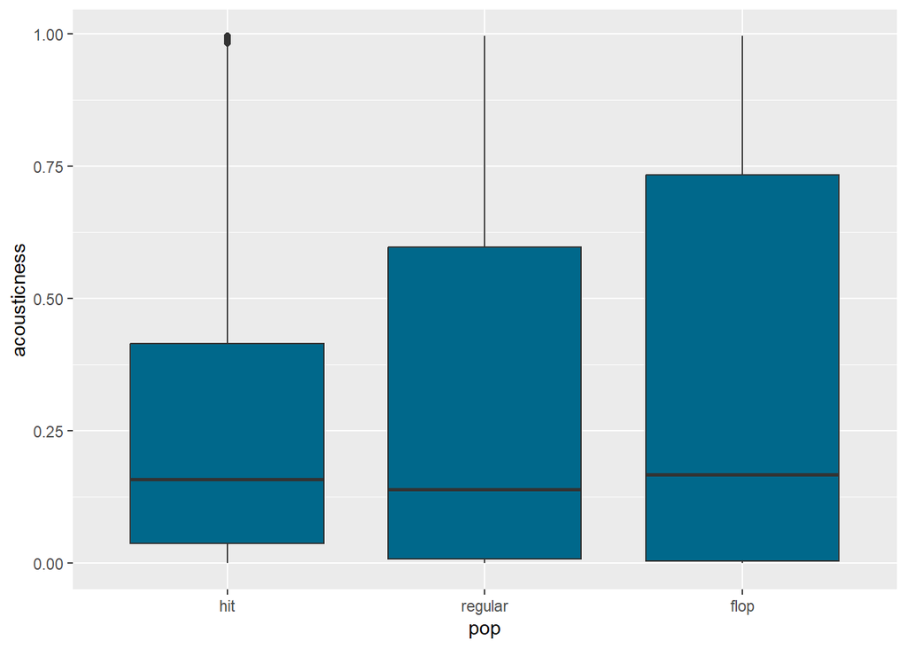

```r
song_data %>%
  ggplot(aes(x = pop, y = acousticness)) +
  geom_boxplot(fill = "deepskyblue4") +
  labs(x = "pop")
```

Even though the median of acousticness is around the same value across all three categories of `pop`, the interquartile range of acousticness of hits is smaller than that of regulars, and then that of flops.

### Missing Values

Here, we check for the missing values of the data to see if any action is needed to better interpret the data set.

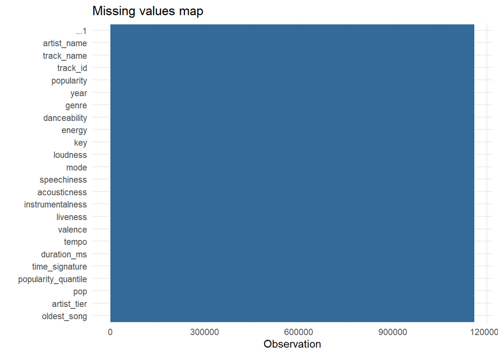

```r
#check for missing values
song_data %>%
  missing_plot()
```

Luckily, the missing value plot shows that there are no missing values of the variables of our interest. Therefore, no actions are needed to deal with the missing values.

## Drop Unnecessary Predictors

Throughout the process of data cleaning and tidying, we created some new variables for better inference and prediction, and now some of the columns are unnecessary. Here, we select only the columns of interest to work with. In the next section, we will start fitting our data using some machine learning model.

```r
#selecting only the necessary variables
song_data = song_data %>%
  select(pop, artist_tier, year, danceability, energy, key, loudness, mode, speechiness, acousticness, instrumentalness, liveness, valence, tempo, duration_ms, time_signature)
```

# Setting Up Models

Here, we wan to set up the model for us to fit our data in. This includes making a training/testing split, creating a recipe, and creating 5 folds for k-fold cross validation.

## Training/Testing Split

We split the data into a training set and a testing set, with training set takin 75% percent of the data set. Also we split the data stratifying over the outcome variable `pop` so that the distribution of `pop` remains the same in both sets.

```r
set.seed(20240517)

song_split = initial_split(song_data, prop = 0.75, strata = "pop")

song_train = training(song_split)
song_test = testing(song_split)
```

## Create Recipe

Here we create the recipe of our model. Since our outcome classification variable, `pop`, is incredibly unbalanced, we want to apply down sampling for better prediction. The reason we choose to down sample instead of up sample is because we have a lot of observations. With the down-sampled training data having 1+2+2 = 5 times the observation of the minority class, `hit`, and the minority class having over 4000 observations, we still have enough data to train on (4404*5 = 22020). Note that in our recipe we include interactions between the correlated predictors and we also center and scale all predictors.

```r
#create song recipe
song_recipe = recipe(pop ~ artist_tier + year + danceability + energy + key + loudness + mode + speechiness + acousticness + instrumentalness + liveness + valence + tempo + duration_ms + time_signature, data = song_train) %>%
  step_dummy(all_nominal_predictors()) %>%
  step_interact(~ danceability:valence) %>%
  step_interact(~ energy:acousticness) %>%
  step_interact(~ energy:loudness) %>%
  step_interact(~ loudness:acousticness) %>%
  step_downsample(pop, under_ratio = 2) %>%
  step_center(all_predictors()) %>%
  step_scale(all_predictors())
```

## K-Fold Cross Validation

Since we have a rather large data set, to ensure that our computing power can comprehend the model fitting, we choose to do k-fold cross validation with 5 folds. We also want to create the folds stratifying over the outcome variable `pop` to reduce error and misinterpretation when fitting the models later.

```r
#create 5 folds for k-fold cross validation, stratify on the outcome variable pop
song_folds = vfold_cv(song_train, v = 5, strata = "pop")
```

# Fit and Tune Models

We will fit our data into 4 different models, which are logistic regression, k-nearest neighbors, elastic net, and random forest. Here we set engine and create workflows of all these models, respectively. Some of the models has hyperparameters to tune: `neighbors` for knn; `penalty` and `mixture` for elastic net; and `mtry`, `trees`, and `min_n` for random forest.

## Logistic Regression

We implement multinomial logistic regression model to explain our data since we have more than two classes in our outcome variable.

```r
log_model = multinom_reg() %>%
  set_engine("nnet") %>%
  set_mode("classification")

log_wflow = workflow() %>%
  add_model(log_model) %>%
  add_recipe(song_recipe)
```

## K-Nearest Neightbors

We set up workflow for knn. Note that we are tuning `neighbors` here and we are creating 8 grids to tune from (1, 8). This means we’re fitting $8$ models.

```r
knn_model = nearest_neighbor(neighbors = tune()) %>%
  set_engine("kknn") %>%
  set_mode("classification")

knn_wflow = workflow() %>%
  add_model(knn_model) %>%
  add_recipe(song_recipe)

knn_grid = grid_regular(neighbors(range = c(1, 8)), levels = 8)
```

## Elastic Net

We set up workflow for elastic net, tuning 8 grids of `penalty` using default values, and 8 grids of `mixture` from (0, 1). This means we’re fitting $8\times8 = 64$ models.

```r
en_model = multinom_reg(mixture = tune(), penalty = tune()) %>%
  set_engine("glmnet") %>%
  set_mode("classification")

en_wflow = workflow() %>%
  add_model(en_model) %>%
  add_recipe(song_recipe)

en_grid = grid_regular(penalty(), mixture(range = c(0, 1)), levels = 8)
```

## Random Forest

We set up workflow for random forest, tuning 10 grids of `mtry` from (1, 10), 5 grids of `trees` from (100, 500), and 4 grids of `min_n` from (2, 5). This means we’re fitting $10\times5\times4 = 200$ models.

```r
rf_model = rand_forest(mtry = tune(), trees = tune(), min_n = tune()) %>%
  set_engine("ranger", importance = "impurity") %>%
  set_mode("classification")

rf_wflow = workflow() %>%
  add_model(rf_model) %>%
  add_recipe(song_recipe)

mtry_values = seq(1, 10, length.out = 10)
trees_values = seq(100, 500, length.out = 5)
min_n_values = seq(2, 5, length.out = 4)

rf_grid = expand_grid(mtry = mtry_values, trees = trees_values, min_n = min_n_values)
```

## Fit and Tune All Models

Finally, we fit all four methods, with the total of $1+8+64+200 = 273$ models each fold into our training set with 5 cross validation folds. We will assess the performance of these models in the next section.

```r
#fit logistic regression
log_fit = fit_resamples(
  object = log_wflow,
  resamples = song_folds
)

#tune knn
knn_tune_fit = tune_grid(
  object = knn_wflow,
  resamples = song_folds,
  grid = knn_grid
)

#tune elastic net;
en_tune_fit = tune_grid(
  object = en_wflow,
  resamples = song_folds,
  grid = en_grid
)

#tune random forest
rf_tune_fit = tune_grid(
  object = rf_wflow,
  resamples = song_folds,
  grid = rf_grid
)

#save the results in .rda files
save(log_fit, file = "log.rda")
save(knn_tune_fit, file = "knn.rda")
save(en_tune_fit, file = "en.rda")
save(rf_tune_fit, file = "rf.rda")
```

```r
#load the results
load("log.rda")
load("knn.rda")
load("en.rda")
load("rf.rda")
```

# Result of All Models

We want to assess he performance of all four models using the metric `roc_auc`, area under the ROC curve. Our goal is to choose the best performing model in terms of `roc_auc` and to see its performance on testing data.

## Logistic Regression

```r
log_metric = collect_metrics(log_fit)

log_metric %>%
  filter(.metric == "roc_auc") %>%
  select(.metric, mean, std_err)
```

```
## # A tibble: 1 × 3
##   .metric  mean  std_err
##   <chr>   <dbl>    <dbl>
## 1 roc_auc 0.811 0.000973
```

Observe that the `roc_auc` from fitting the logistic regression is estimated to be 0.8109.

## K-Nearest Neighbors

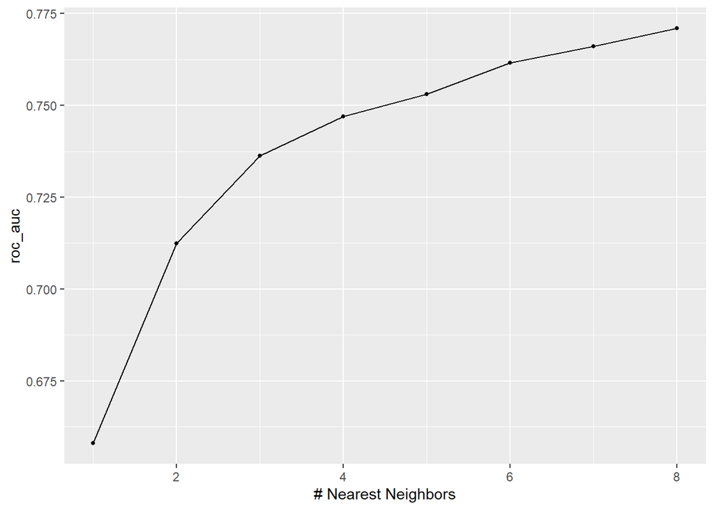

```r
#create the plot for roc_auc of knn
autoplot(knn_tune_fit, metric = "roc_auc")
```

From the graph, we can see the best performing knn model has `roc_auc` value around 0.77.

## Elastic Net

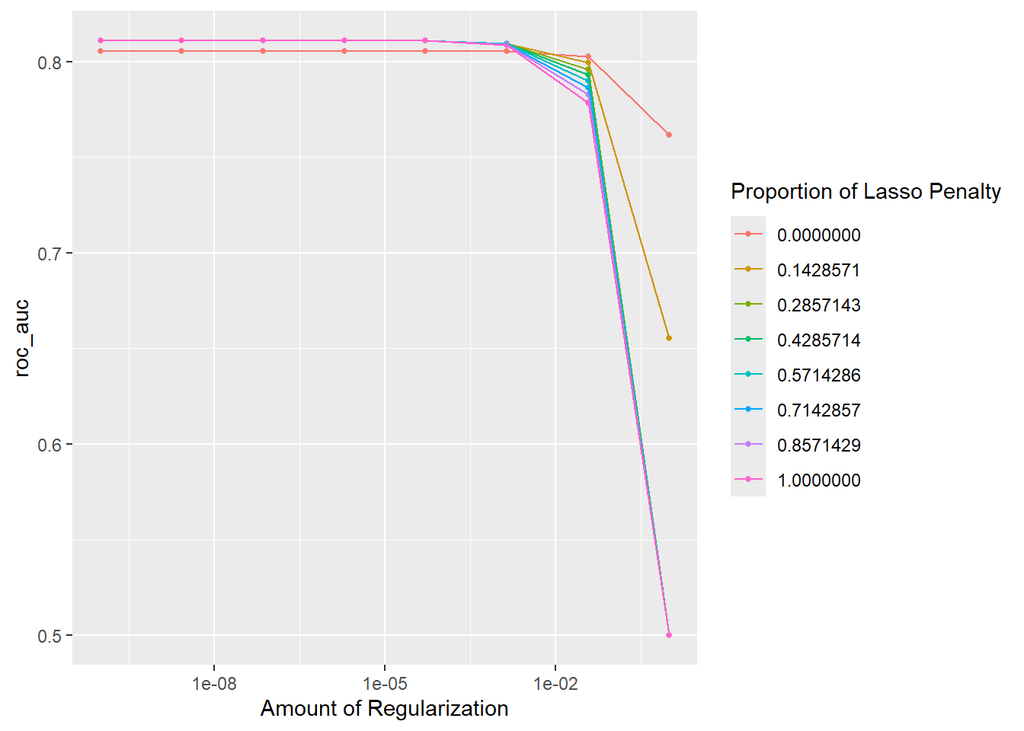

```r
#create the plot for roc_auc of elantic net
autoplot(en_tune_fit, metric = "roc_auc")
```

From the graph, we can see the best performing elastic net model has `roc_auc` value around 0.81.

## Random Forest

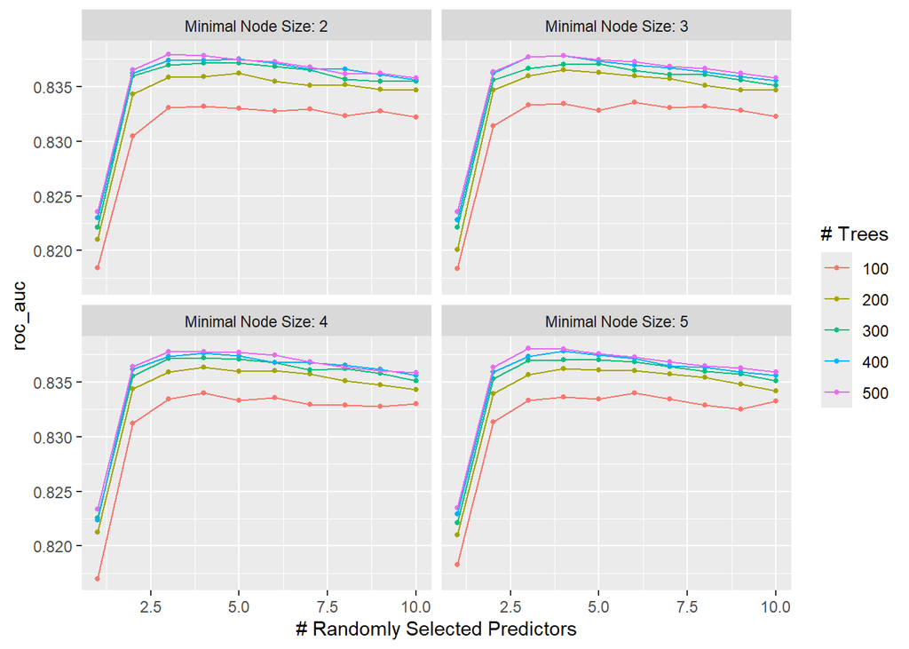

```r
#create the plot for roc_auc of elantic net
autoplot(rf_tune_fit, metric = "roc_auc")
```

From the graph, we can see the best performing random forest model has `roc_auc` value around 0.837.

## Select the Best Performing Model

```r
#select best rf model
show_best(rf_tune_fit, n = 1, metric = "roc_auc")
```

```
## # A tibble: 1 × 9
##    mtry trees min_n .metric .estimator  mean     n  std_err .config
##   <dbl> <dbl> <dbl> <chr>   <chr>      <dbl> <int>    <dbl> <chr>
## 1     3   500     5 roc_auc hand_till  0.838     5 0.000802 Preprocessor1_Model…
```

# Test the Best Model

```r
#fit the best model to our testing set
best_rf = show_best(rf_tune_fit, n = 1, metric = "roc_auc")

final_wflow = finalize_workflow(rf_wflow, best_rf)
final_fit = fit(final_wflow, song_train)

#save the final fit in .rda file
save(final_fit, file = "final_fit.rda")
```

```r
#load final fit
load("final_fit.rda")
```

Here, we want to use our best model to predict and fit the testing data and see how it performs. Specifically, we will be looking at its ROC curves, area under the ROC curve, and the heat map of confusion matrix.

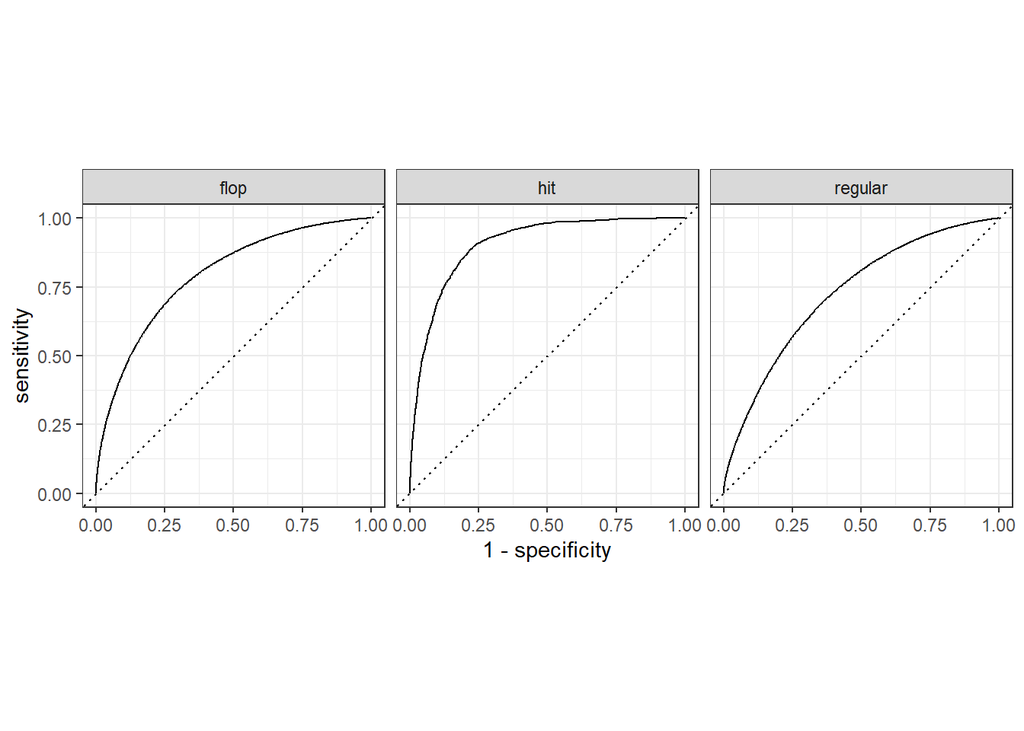

```r
#use model to predict testing set
final_fit_test = augment(final_fit, new_data = song_test) %>%
  select(pop, starts_with(".pred"))

roc_curve(final_fit_test, truth = pop, .pred_hit:.pred_flop) %>%
  autoplot()
```

```r
roc_auc(final_fit_test, truth = pop, .pred_hit:.pred_flop)
```

```
## # A tibble: 1 × 3
##   .metric .estimator .estimate
##   <chr>   <chr>          <dbl>
## 1 roc_auc hand_till      0.843
```

From the graph we can see that the model performed relatively well in predicting the three classes, particularly doing best at predicting `hits`, which is pretty surprising to me since `hits` have the least amount of observations. Also, the overall `roc_auc` is 0.843, which is even better then our training `roc_auc`, 0.838. Though this may be caused by variability and randomness, the fact that we get a higher `roc_auc` for out testing data is still pretty impressive.

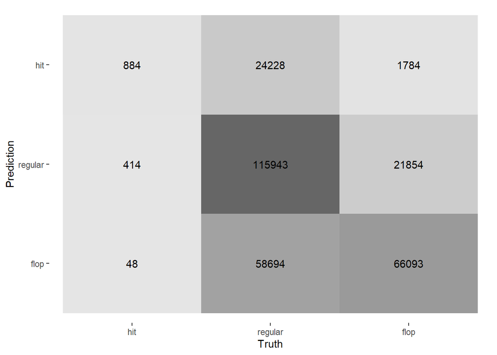

```r
conf_mat(final_fit_test, truth = pop, .pred_class) %>%
  autoplot(type = "heatmap")
```

Looking at the heat map of the confusion matrix, we can see that we got 65.68% of `hit`, 58.30% of `regular`, and 73.66% of `flop` correct. The overall accuracy is 63.09%, which is not excellent but also not bad at all. What’s also notable is that we rarely mistake a `hit` for a `flop`(3.57%) and rarely mistake a `flop` for a `hit`(1.99%), which shows that the model is successful to some extent, while most error occur due to mistaking the `regular` class.

# Conclusion and Future Improvements

The overall result and discovery of this project is rather satisfying. We started off cleaning our data, making transformation of predictors to better interpret the effect of artists, as well as changing the outcome variable from numeric to nominal for easier understanding. Then, we also spent much effort visualizing some of the characteristics of our data set to understand it to a certain extent before we start fitting our data in the model. For model fitting, we fitted and tuned our data using 4 machine learning models, which are logistic regression, k-nearest neighbors, elastic net, and random forest. Out of all these methods, random forest and elastic net performed the best, this could be due to the presence of collinearity which we didn’t really accommodate for. One further improvement I would make is to perform principle components analysis(PCA) on the correlated predictors to make sure our outcome not being affected by such factor.

As for model selecting, the best performing model(random forest) successfully predicted over 63% of the result in our testing set, in which we successfully predicted 65% of the true hits. While this may seem like an acceptable result, if we look from another perspective, of those observation we predicted to be a hit, only 3.29% of them ended up actually being a hit. This showed spaces for improvements and that further changes should be applied to better predict the model.

It’s fair to say that randomness is a huge factor why the “hits” become hits. The attempt we made in this project is trying to grasp an underlying structure, if any, of songs becoming hits. The results we see did revealed some of the underlying structures. In future improvements, we can test out other models, perhaps some other tree-based models like boosted trees, to see if those models can explain our data better. Another issue we ran into over the course of this project is the computational power not being able to handle that many observation while applying tuning and cross-validation at the same time. Given better computational power, we can try to fit our model with 10 folds in stead of 5, create more grids to fit on, and perhaps see some improvements with those changes.

Overall, I think this is a successful learning experience for me and I really enjoyed every stage of this course, from cleaning to tuning. The way these concepts were introduced to me had me finding myself really attracted to the ideas of machine learning and would want to take a deeper dive into the realm of machine learning. All I have to say is I had a blast!